# Lecture 3: Lists and Data Frames

### (Copied from R programming lecture notes, use for code reference only.)

## 1. Lists

- Lists provide a way to store **information of different types within a single data structure**
- Remember that vectors and matrices restrict us to only **one data type** at a time
- That is we cannot mix, for example, characters and numbers within a vector or matrix
- **Many functions in R return information stored in lists**
- **Consider the following example wherein we store information about a family. Not all this information is of the same type**

```r
family1 <- list(husband="Fred", wife="Wilma", numofchildren=3,
                agesofkids=c(8,11,14))

length(family1)  # Has 4 elements
```

```
## [1] 4
```

```r
family1
```

```
## $husband
## [1] "Fred"
##
## $wife
## [1] "Wilma"
##
## $numofchildren
## [1] 3
##
## $agesofkids
## [1]  8 11 14
```

```r
str(family1)
```

```
## List of 4
##  $ husband      : chr "Fred"
##  $ wife         : chr "Wilma"
##  $ numofchildren: num 3
##  $ agesofkids   : num [1:3] 8 11 14
```

### 1.1 Name a list

#### If possible, always create named elements. It is easier for humans to index into a named list

```r
family1 <- list(husband="Fred", wife="Wilma", numofchildren=3,
                agesofkids=c(8,11,14))

# If the list elements have names then use "$" to access the element

family1$agesofkids
```

```
## [1]  8 11 14
```

```r
family1$agesofkids[1:2]
```

```
## [1]  8 11
```

#### If the list elements have no names then you have to use numeric indexing

```r
family2 <- list("Barney","Betty",2,c(4,6))

family2[4]    # Accesses the 4th index and associated element
```

```
## [[1]]
## [1] 4 6
```

```r
family2[[4]] # Accesses the 4th element value only - more direct
```

```
## [1] 4 6
```

```r
family2[3:4] # Get 3rd and 4th indices and associate values
```

```
## [[1]]
## [1] 2
##
## [[2]]
## [1] 4 6
```

### 1.2 `unlist()`

#### Use the `unlist` function to turn a list into a vector. Since the list usually has mixed data types then the elements will be converted to a single type.

```r
family1 <- list(husband="Fred", wife="Wilma", numofchildren=3,
                agesofkids=c(8,11,14))
unlist(family1)
```

```
##       husband          wife numofchildren   agesofkids1   agesofkids2
##        "Fred"       "Wilma"           "3"           "8"          "11"
##   agesofkids3
##          "14"
```

```r
as.numeric(unlist(family1))
```

```
## [1] NA NA  3  8 11 14
```

### 1.3 When we use lists?

#### As newcomers to R we usually doesn’t create lists except in two major cases:

- We are writing a **function** that does some interesting stuff and we want to **return to the user a structure that has information of varying types**
- **As a precursor to creating a a data frame, which represents a hybrid object with characteristics of a list and a matrix**

#### As an example of the first case, R has lots of statistical functions that return lists of information.

```r
data(mtcars)   # Load mtcars into the environment

mylm <- lm(mpg ~ wt, data = mtcars)

print(mylm)
```

```
##
## Call:
## lm(formula = mpg ~ wt, data = mtcars)
##
## Coefficients:
## (Intercept)           wt
##      37.285       -5.344
```

```r
# But there is a lot more information

typeof(mylm)
```

```
## [1] "list"
```

```r
str(mylm,give.attr=F)  # Lots of stuff here
```

```
## List of 12
##  $ coefficients : Named num [1:2] 37.29 -5.34
##  $ residuals    : Named num [1:32] -2.28 -0.92 -2.09 1.3 -0.2 ...
##  $ effects      : Named num [1:32] -113.65 -29.116 -1.661 1.631 0.111 ...
##  $ rank         : int 2
##  $ fitted.values: Named num [1:32] 23.3 21.9 24.9 20.1 18.9 ...
##  $ assign       : int [1:2] 0 1
##  $ qr           :List of 5
##   ..$ qr   : num [1:32, 1:2] -5.657 0.177 0.177 0.177 0.177 ...
##   ..$ qraux: num [1:2] 1.18 1.05
##   ..$ pivot: int [1:2] 1 2
##   ..$ tol  : num 1e-07
##   ..$ rank : int 2
##  $ df.residual  : int 30
##  $ xlevels      : Named list()
##  $ call         : language lm(formula = mpg ~ wt, data = mtcars)
##  $ terms        :Classes 'terms', 'formula'  language mpg ~ wt
##  $ model        :'data.frame':   32 obs. of  2 variables:
##   ..$ mpg: num [1:32] 21 21 22.8 21.4 18.7 18.1 14.3 24.4 22.8 19.2 ...
##   ..$ wt : num [1:32] 2.62 2.88 2.32 3.21 3.44 ...
```

```r
names(mylm)
```

```
##  [1] "coefficients"  "residuals"     "effects"       "rank"
##  [5] "fitted.values" "assign"        "qr"            "df.residual"
##  [9] "xlevels"       "call"          "terms"         "model"
```

```r
lm(mpg ~ wt, data = mtcars)$coefficients
```

```
## (Intercept)          wt
##   37.285126   -5.344472
```

#### Some other basic R functions will return a list - such as some of the character functions:

```r
mystring <- "This is a test"

mys <- strsplit(mystring, " ")

str(mys)
```

```
## List of 1
##  $ : chr [1:4] "This" "is" "a" "test"
```

```r
my.summary <- function(x) {
 return.list <- list()
 return.list$mean <- mean(x)
 return.list$sd <- sd(x)
 return.list$var <- var(x)
 return(return.list)
}

my.summary(1:10)
```

```
## $mean
## [1] 5.5
##
## $sd
## [1] 3.02765
##
## $var
## [1] 9.166667
```

### 1.4 Lists - sapply/lapply

#### Remember the `sapply` command ? We use it to apply a function over each element of a list or a vector. This helps us avoid having to write a “for-loop” every time we want to process a list or a vector.

```r
# sapply( vector_or_list, function_to_apply_to_each element)

family1 <- list(husband="Fred", wife="Wilma", numofchildren=3,
agesofkids=c(8,11,14))

sapply(family1,class)
```

```
##       husband          wife numofchildren    agesofkids
##   "character"   "character"     "numeric"     "numeric"
```

```r
sapply(family1,length)
```

```
##       husband          wife numofchildren    agesofkids
##             1             1             1             3
```

#### `sapply` tries to return a “simplified” version of the output (either a vector or matrix) hence the “s” in the “sapply”. If you don’t use something like sapply then the example on the previous slide would look this:

```r
# sapply( vector_or_list, function_to_apply_to_each element)

family1 <- list(husband="Fred", wife="Wilma", numofchildren=3,
                agesofkids=c(8,11,14))

for (ii in 1:length(family1)) {
  cat(names(family1)[ii]," : ",class(family1[[ii]]),"\n")
}
```

```
## husband  :  character
## wife  :  character
## numofchildren  :  numeric
## agesofkids  :  numeric
```

```r
# More involved than just doing

sapply(family1,class)
```

```
##       husband          wife numofchildren    agesofkids
##   "character"   "character"     "numeric"     "numeric"
```

#### What is `lapply`?

- **Similar to `sapply`, the `lapply` function let’s you “apply” some function over each element of a list or vector.**
- **It will return a list version of the output hence the “l” in the “lapply”.**
- **So deciding between `sapply` and `lapply` simply is a question of format. What do you want back ? A vector or list ? Most of the time I use `sapply`.**

```r
# lapply( vector_or_list, function_to_apply_to_each element)

family1 <- list(husband="Fred", wife="Wilma", numofchildren=3,
                agesofkids=c(8,11,14))

lapply(family1,class)
```

```
## $husband
## [1] "character"
##
## $wife
## [1] "character"
##
## $numofchildren
## [1] "numeric"
##
## $agesofkids
## [1] "numeric"
```

```r
lapply(family1,mean)
```

```
## $husband
## [1] NA
##
## $wife
## [1] NA
##
## $numofchildren
## [1] 3
##
## $agesofkids
## [1] 11
```

```r
my.func <- function(x){
     if(class(x)=="numeric") {
          return(mean(x))
     }
}

lapply(family1, my.func)
```

```
## $husband
## NULL
##
## $wife
## NULL
##
## $numofchildren
## [1] 3
##
## $agesofkids
## [1] 11
```

## 2. Data Frames

- A data frame is **a special type of list that contains data in a format that allows for easier manipulation, reshaping, and open-ended analysis**
- **Data frames are tightly coupled collections of variables. It is one of the more important constructs you will encounter when using R so learn all you can about it**
- A data frame is **an analogue to the Excel spreadsheet but is much more flexible for storing, manipulating, and analyzing data**
- **Data frames can be constructed from existing vectors, lists, or matrices. Many times they are created by reading in comma delimited files, (CSV files), using the read.table command**
- **Once you become accustomed to working with data frames, R becomes so much easier to use**

### 2.1 An example of data frame

#### Here we have 2 character vectors and 2 numeric vectors. Let’s say we want to do some summary on them:

```r
names <- c("P1","P2","P3","P4","P5")
temp <- c(98.2,101.3,97.2,100.2,98.5)
pulse <- c(66,72,83,85,90)
gender <- c("M","F","M","M","F")

# We could write a for loop to get information for each patient
for (ii in 1:length(gender)) {
print.string = c(names[ii],temp[ii],pulse[ii],gender[ii])
print(print.string)
}
```

```
## [1] "P1"   "98.2" "66"   "M"
## [1] "P2"    "101.3" "72"    "F"
## [1] "P3"   "97.2" "83"   "M"
## [1] "P4"    "100.2" "85"    "M"
## [1] "P5"   "98.5" "90"   "F"
```

### 2.2 Create a data frame

#### That doesn’t generalize at all. Use the `dataframe()` function to create a data frame. It looks like a matrix but allows for mixed data types

```r
names <- c("P1","P2","P3","P4","P5")
temp <- c(98.2,101.3,97.2,100.2,98.5)
pulse <- c(66,72,83,85,90)
gender <- c("M","F","M","M","F")
my_df <- data.frame(names,temp,pulse,gender) # Much more flexible
my_df
```

```
##   names  temp pulse gender
## 1    P1  98.2    66      M
## 2    P2 101.3    72      F
## 3    P3  97.2    83      M
## 4    P4 100.2    85      M
## 5    P5  98.5    90      F
```

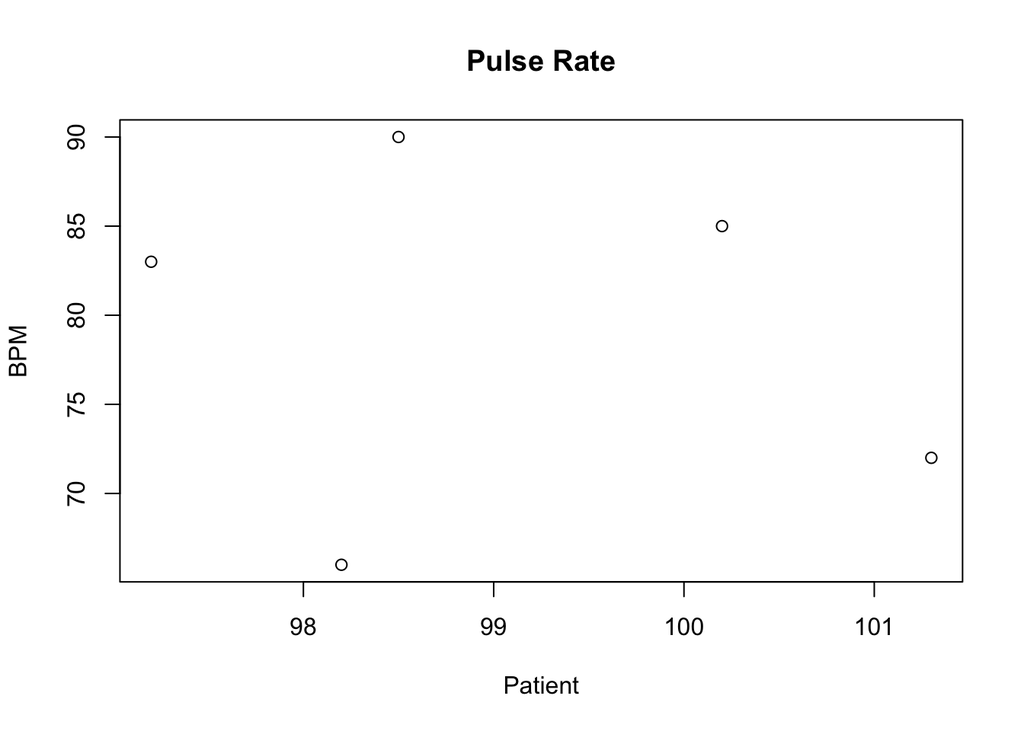

```r
plot(my_df$pulse ~ my_df$temp,main="Pulse Rate",xlab="Patient",ylab="BPM")
```

```r
mean(my_df[,2:3])
```

```
## [1] NA
```

### 2.3 Useful datasets in the format of data frame

#### R comes with a variety of built-in data sets that are very useful for getting used to data sets and how to manipulate them.

```r
library(help="datasets")
```

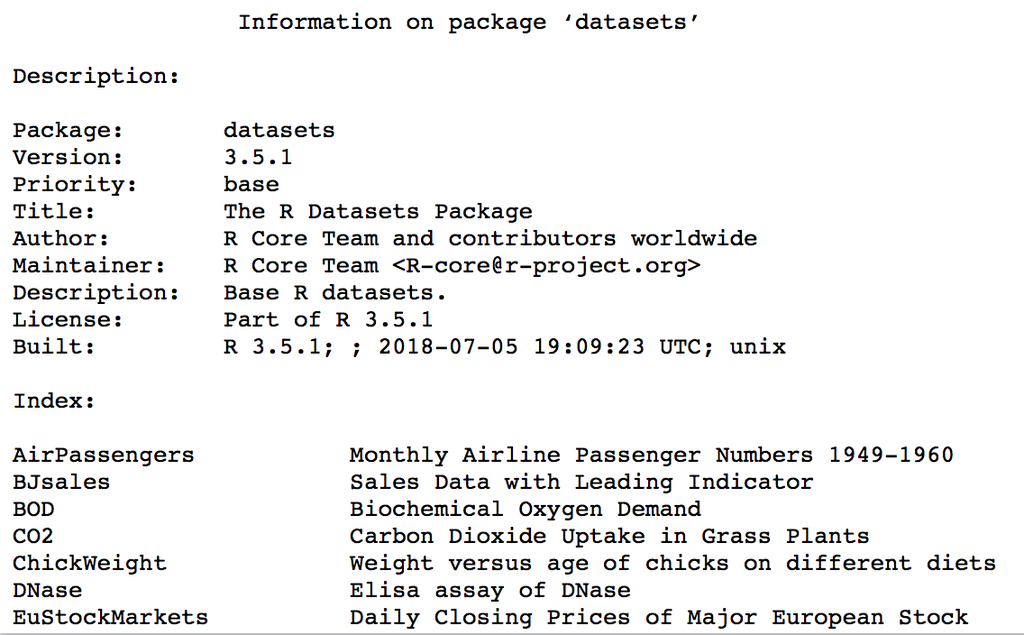

```r
data(mtcars)
str(mtcars)
```

```
## 'data.frame':    32 obs. of  11 variables:
##  $ mpg : num  21 21 22.8 21.4 18.7 18.1 14.3 24.4 22.8 19.2 ...
##  $ cyl : num  6 6 4 6 8 6 8 4 4 6 ...
##  $ disp: num  160 160 108 258 360 ...
##  $ hp  : num  110 110 93 110 175 105 245 62 95 123 ...
##  $ drat: num  3.9 3.9 3.85 3.08 3.15 2.76 3.21 3.69 3.92 3.92 ...
##  $ wt  : num  2.62 2.88 2.32 3.21 3.44 ...
##  $ qsec: num  16.5 17 18.6 19.4 17 ...
##  $ vs  : num  0 0 1 1 0 1 0 1 1 1 ...
##  $ am  : num  1 1 1 0 0 0 0 0 0 0 ...
##  $ gear: num  4 4 4 3 3 3 3 4 4 4 ...
##  $ carb: num  4 4 1 1 2 1 4 2 2 4 ...
```

```r
nrow(mtcars) # How many rows does it have ?
```

```
## [1] 32
```

```r
ncol(mtcars) # How many columns are there ?
```

```
## [1] 11
```

```r
rownames(mtcars)
```

```
##  [1] "Mazda RX4"           "Mazda RX4 Wag"       "Datsun 710"
##  [4] "Hornet 4 Drive"      "Hornet Sportabout"   "Valiant"
##  [7] "Duster 360"          "Merc 240D"           "Merc 230"
## [10] "Merc 280"            "Merc 280C"           "Merc 450SE"
## [13] "Merc 450SL"          "Merc 450SLC"         "Cadillac Fleetwood"
## [16] "Lincoln Continental" "Chrysler Imperial"   "Fiat 128"
## [19] "Honda Civic"         "Toyota Corolla"      "Toyota Corona"
## [22] "Dodge Challenger"    "AMC Javelin"         "Camaro Z28"
## [25] "Pontiac Firebird"    "Fiat X1-9"           "Porsche 914-2"
## [28] "Lotus Europa"        "Ford Pantera L"      "Ferrari Dino"
## [31] "Maserati Bora"       "Volvo 142E"
```

```r
rownames(mtcars) <- 1:32

head(mtcars)
```

```
##    mpg cyl disp  hp drat    wt  qsec vs am gear carb
## 1 21.0   6  160 110 3.90 2.620 16.46  0  1    4    4
## 2 21.0   6  160 110 3.90 2.875 17.02  0  1    4    4
## 3 22.8   4  108  93 3.85 2.320 18.61  1  1    4    1
## 4 21.4   6  258 110 3.08 3.215 19.44  1  0    3    1
## 5 18.7   8  360 175 3.15 3.440 17.02  0  0    3    2
## 6 18.1   6  225 105 2.76 3.460 20.22  1  0    3    1
```

```r
rownames(mtcars) = paste("car",1:32,sep="_")
head(mtcars)
```

```
##        mpg cyl disp  hp drat    wt  qsec vs am gear carb
## car_1 21.0   6  160 110 3.90 2.620 16.46  0  1    4    4
## car_2 21.0   6  160 110 3.90 2.875 17.02  0  1    4    4
## car_3 22.8   4  108  93 3.85 2.320 18.61  1  1    4    1
## car_4 21.4   6  258 110 3.08 3.215 19.44  1  0    3    1
## car_5 18.7   8  360 175 3.15 3.440 17.02  0  0    3    2
## car_6 18.1   6  225 105 2.76 3.460 20.22  1  0    3    1
```

### 2.4 Select, remove, exclude in data frame

#### There are various ways to select, remove, or exclude rows and columns

```r
head(mtcars[,-11])
```

```
##        mpg cyl disp  hp drat    wt  qsec vs am gear
## car_1 21.0   6  160 110 3.90 2.620 16.46  0  1    4
## car_2 21.0   6  160 110 3.90 2.875 17.02  0  1    4
## car_3 22.8   4  108  93 3.85 2.320 18.61  1  1    4
## car_4 21.4   6  258 110 3.08 3.215 19.44  1  0    3
## car_5 18.7   8  360 175 3.15 3.440 17.02  0  0    3
## car_6 18.1   6  225 105 2.76 3.460 20.22  1  0    3
```

```r
head(mtcars) # Notice that carb is included
```

```
##        mpg cyl disp  hp drat    wt  qsec vs am gear carb
## car_1 21.0   6  160 110 3.90 2.620 16.46  0  1    4    4
## car_2 21.0   6  160 110 3.90 2.875 17.02  0  1    4    4
## car_3 22.8   4  108  93 3.85 2.320 18.61  1  1    4    1
## car_4 21.4   6  258 110 3.08 3.215 19.44  1  0    3    1
## car_5 18.7   8  360 175 3.15 3.440 17.02  0  0    3    2
## car_6 18.1   6  225 105 2.76 3.460 20.22  1  0    3    1
```

```r
head(mtcars[,-3:-5]) # Print all columns except for columns 3 through 5
```

```
##        mpg cyl    wt  qsec vs am gear carb
## car_1 21.0   6 2.620 16.46  0  1    4    4
## car_2 21.0   6 2.875 17.02  0  1    4    4
## car_3 22.8   4 2.320 18.61  1  1    4    1
## car_4 21.4   6 3.215 19.44  1  0    3    1
## car_5 18.7   8 3.440 17.02  0  0    3    2
## car_6 18.1   6 3.460 20.22  1  0    3    1
```

```r
head(mtcars[,c(-3,-5)]) # Print all columns except for colums 3 AND 5
```

```
##        mpg cyl  hp    wt  qsec vs am gear carb
## car_1 21.0   6 110 2.620 16.46  0  1    4    4
## car_2 21.0   6 110 2.875 17.02  0  1    4    4
## car_3 22.8   4  93 2.320 18.61  1  1    4    1
## car_4 21.4   6 110 3.215 19.44  1  0    3    1
## car_5 18.7   8 175 3.440 17.02  0  0    3    2
## car_6 18.1   6 105 3.460 20.22  1  0    3    1
```

```r
mtcars[mtcars$mpg >= 30.0,]
```

```
##         mpg cyl disp  hp drat    wt  qsec vs am gear carb
## car_18 32.4   4 78.7  66 4.08 2.200 19.47  1  1    4    1
## car_19 30.4   4 75.7  52 4.93 1.615 18.52  1  1    4    2
## car_20 33.9   4 71.1  65 4.22 1.835 19.90  1  1    4    1
## car_28 30.4   4 95.1 113 3.77 1.513 16.90  1  1    5    2
```

```r
mtcars[mtcars$mpg >= 30.0,2:6]
```

```
##        cyl disp  hp drat    wt
## car_18   4 78.7  66 4.08 2.200
## car_19   4 75.7  52 4.93 1.615
## car_20   4 71.1  65 4.22 1.835
## car_28   4 95.1 113 3.77 1.513
```

```r
mtcars[mtcars$mpg >= 30.0 & mtcars$cyl < 6,]
```

```
##         mpg cyl disp  hp drat    wt  qsec vs am gear carb
## car_18 32.4   4 78.7  66 4.08 2.200 19.47  1  1    4    1
## car_19 30.4   4 75.7  52 4.93 1.615 18.52  1  1    4    2
## car_20 33.9   4 71.1  65 4.22 1.835 19.90  1  1    4    1
## car_28 30.4   4 95.1 113 3.77 1.513 16.90  1  1    5    2
```

#### Find all rows that correspond to Automatic and Count them

```r
mtcars[mtcars$am==0,]
```

```
##         mpg cyl  disp  hp drat    wt  qsec vs am gear carb
## car_4  21.4   6 258.0 110 3.08 3.215 19.44  1  0    3    1
## car_5  18.7   8 360.0 175 3.15 3.440 17.02  0  0    3    2
## car_6  18.1   6 225.0 105 2.76 3.460 20.22  1  0    3    1
## car_7  14.3   8 360.0 245 3.21 3.570 15.84  0  0    3    4
## car_8  24.4   4 146.7  62 3.69 3.190 20.00  1  0    4    2
## car_9  22.8   4 140.8  95 3.92 3.150 22.90  1  0    4    2
## car_10 19.2   6 167.6 123 3.92 3.440 18.30  1  0    4    4
## car_11 17.8   6 167.6 123 3.92 3.440 18.90  1  0    4    4
## car_12 16.4   8 275.8 180 3.07 4.070 17.40  0  0    3    3
## car_13 17.3   8 275.8 180 3.07 3.730 17.60  0  0    3    3
## car_14 15.2   8 275.8 180 3.07 3.780 18.00  0  0    3    3
## car_15 10.4   8 472.0 205 2.93 5.250 17.98  0  0    3    4
## car_16 10.4   8 460.0 215 3.00 5.424 17.82  0  0    3    4
## car_17 14.7   8 440.0 230 3.23 5.345 17.42  0  0    3    4
## car_21 21.5   4 120.1  97 3.70 2.465 20.01  1  0    3    1
## car_22 15.5   8 318.0 150 2.76 3.520 16.87  0  0    3    2
## car_23 15.2   8 304.0 150 3.15 3.435 17.30  0  0    3    2
## car_24 13.3   8 350.0 245 3.73 3.840 15.41  0  0    3    4
## car_25 19.2   8 400.0 175 3.08 3.845 17.05  0  0    3    2
```

```r
nrow(mtcars[mtcars$am == 0,])
```

```
## [1] 19
```

```r
nrow(mtcars[mtcars$am == 1,])
```

```
## [1] 13
```

#### Extract all rows whose MPG value exceeds the mean MPG for the entire data frame

```r
mtcars[mtcars$mpg > mean(mtcars$mpg),]
```

```
##         mpg cyl  disp  hp drat    wt  qsec vs am gear carb
## car_1  21.0   6 160.0 110 3.90 2.620 16.46  0  1    4    4
## car_2  21.0   6 160.0 110 3.90 2.875 17.02  0  1    4    4
## car_3  22.8   4 108.0  93 3.85 2.320 18.61  1  1    4    1
## car_4  21.4   6 258.0 110 3.08 3.215 19.44  1  0    3    1
## car_8  24.4   4 146.7  62 3.69 3.190 20.00  1  0    4    2
## car_9  22.8   4 140.8  95 3.92 3.150 22.90  1  0    4    2
## car_18 32.4   4  78.7  66 4.08 2.200 19.47  1  1    4    1
## car_19 30.4   4  75.7  52 4.93 1.615 18.52  1  1    4    2
## car_20 33.9   4  71.1  65 4.22 1.835 19.90  1  1    4    1
## car_21 21.5   4 120.1  97 3.70 2.465 20.01  1  0    3    1
## car_26 27.3   4  79.0  66 4.08 1.935 18.90  1  1    4    1
## car_27 26.0   4 120.3  91 4.43 2.140 16.70  0  1    5    2
## car_28 30.4   4  95.1 113 3.77 1.513 16.90  1  1    5    2
## car_32 21.4   4 121.0 109 4.11 2.780 18.60  1  1    4    2
```

```r
# Find the quartiles for the MPG vector
quantile(mtcars$mpg)
```

```
##     0%    25%    50%    75%   100%
## 10.400 15.425 19.200 22.800 33.900
```

```r
# Now find the cars for which the MPG exceeds the 75% value:
mtcars[mtcars$mpg > quantile(mtcars$mpg)[4],]
```

```
##         mpg cyl  disp  hp drat    wt  qsec vs am gear carb
## car_8  24.4   4 146.7  62 3.69 3.190 20.00  1  0    4    2
## car_18 32.4   4  78.7  66 4.08 2.200 19.47  1  1    4    1
## car_19 30.4   4  75.7  52 4.93 1.615 18.52  1  1    4    2
## car_20 33.9   4  71.1  65 4.22 1.835 19.90  1  1    4    1
## car_26 27.3   4  79.0  66 4.08 1.935 18.90  1  1    4    1
## car_27 26.0   4 120.3  91 4.43 2.140 16.70  0  1    5    2
## car_28 30.4   4  95.1 113 3.77 1.513 16.90  1  1    5    2
```

#### What columns appear to be factors ? Variables with only a “few” different unique values perhaps ?

```r
str(mtcars)
```

```
## 'data.frame':    32 obs. of  11 variables:
##  $ mpg : num  21 21 22.8 21.4 18.7 18.1 14.3 24.4 22.8 19.2 ...
##  $ cyl : num  6 6 4 6 8 6 8 4 4 6 ...
##  $ disp: num  160 160 108 258 360 ...
##  $ hp  : num  110 110 93 110 175 105 245 62 95 123 ...
##  $ drat: num  3.9 3.9 3.85 3.08 3.15 2.76 3.21 3.69 3.92 3.92 ...
##  $ wt  : num  2.62 2.88 2.32 3.21 3.44 ...
##  $ qsec: num  16.5 17 18.6 19.4 17 ...
##  $ vs  : num  0 0 1 1 0 1 0 1 1 1 ...
##  $ am  : num  1 1 1 0 0 0 0 0 0 0 ...
##  $ gear: num  4 4 4 3 3 3 3 4 4 4 ...
##  $ carb: num  4 4 1 1 2 1 4 2 2 4 ...
```

```r
unique(mtcars$am) # Tells us what the unique values are
```

```
## [1] 1 0
```

#### If one column of the data frame is a categorical variable

```r
# If we summarize one of these potential factors right now, R will treat it as
# being purely numeric which we might not want
summary(mtcars$am)
```

```
##    Min. 1st Qu.  Median    Mean 3rd Qu.    Max.
##  0.0000  0.0000  0.0000  0.4062  1.0000  1.0000
```

```r
# So this really isn't helpful since we know that the "am" values are
# transmission types
mtcars$am <- factor(mtcars$am, levels = c(0,1), labels = c("Auto","Man") )
summary(mtcars$am)
```

```
## Auto  Man
##   19   13
```

### 2.5 Add columns to data frame

#### We can add columns to a data frame. Let’s say we want to create a new column called “mpgrate” that, based on the output of the quantile command, will have a rating of the that car’s MPG in terms of “horrible”,“bad”,“good”,“great”

```r
# The labels could be more scientific but this is still a good use case. There
# are a couple of ways to do this:

data(mtcars) # Reload a "pure" copy of mtcars
mpgrate <- cut(mtcars$mpg,
               breaks = quantile(mtcars$mpg),
               labels=c("horrible","Bad","Good","Great"),include.lowest=T)
mtcars <- cbind(mtcars,mpgrate)
# or
mtcars$mpgrate <- mpgrate # The column just magically appears !
head(mtcars)
```

```
##                    mpg cyl disp  hp drat    wt  qsec vs am gear carb
## Mazda RX4         21.0   6  160 110 3.90 2.620 16.46  0  1    4    4
## Mazda RX4 Wag     21.0   6  160 110 3.90 2.875 17.02  0  1    4    4
## Datsun 710        22.8   4  108  93 3.85 2.320 18.61  1  1    4    1
## Hornet 4 Drive    21.4   6  258 110 3.08 3.215 19.44  1  0    3    1
## Hornet Sportabout 18.7   8  360 175 3.15 3.440 17.02  0  0    3    2
## Valiant           18.1   6  225 105 2.76 3.460 20.22  1  0    3    1
##                   mpgrate
## Mazda RX4            Good
## Mazda RX4 Wag        Good
## Datsun 710           Good
## Hornet 4 Drive       Good
## Hornet Sportabout     Bad
## Valiant               Bad
```

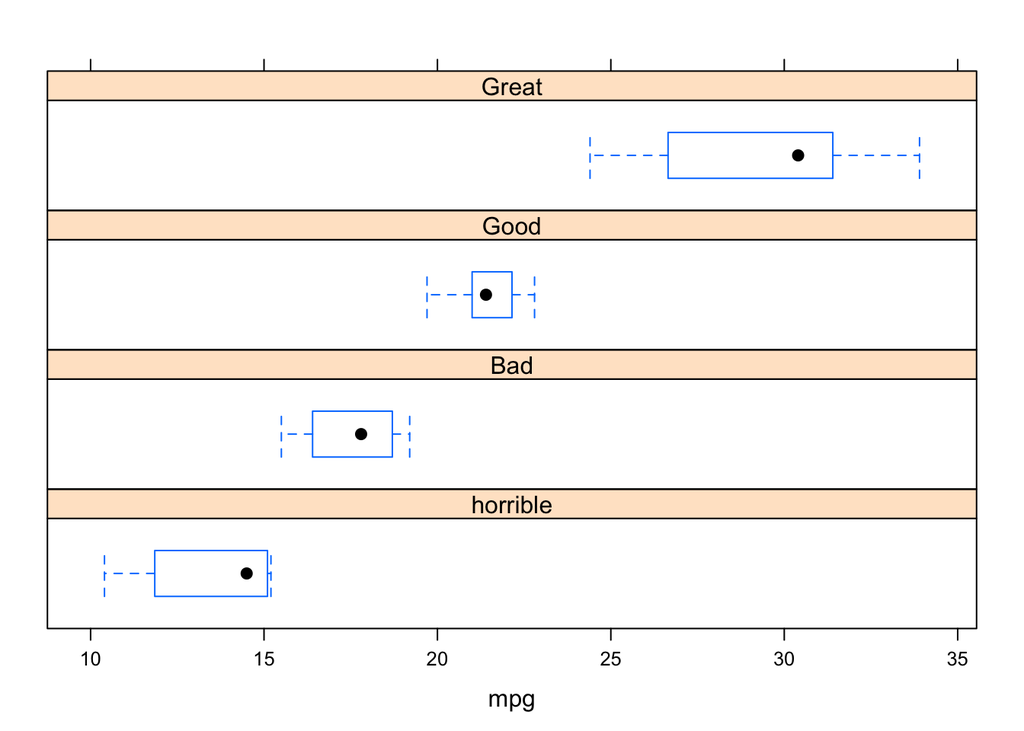

```r
library(lattice)
bwplot(~mpg|mpgrate,data=mtcars,layout=c(1,4))
```

#### You can also use the `transform()` command to change the types/classes of the columns

```r
head(mtcars)
```

```
##                    mpg cyl disp  hp drat    wt  qsec vs am gear carb
## Mazda RX4         21.0   6  160 110 3.90 2.620 16.46  0  1    4    4
## Mazda RX4 Wag     21.0   6  160 110 3.90 2.875 17.02  0  1    4    4
## Datsun 710        22.8   4  108  93 3.85 2.320 18.61  1  1    4    1
## Hornet 4 Drive    21.4   6  258 110 3.08 3.215 19.44  1  0    3    1
## Hornet Sportabout 18.7   8  360 175 3.15 3.440 17.02  0  0    3    2
## Valiant           18.1   6  225 105 2.76 3.460 20.22  1  0    3    1
##                   mpgrate
## Mazda RX4            Good
## Mazda RX4 Wag        Good
## Datsun 710           Good
## Hornet 4 Drive       Good
## Hornet Sportabout     Bad
## Valiant               Bad
```

```r
transform(mtcars,wt = (wt*1000), qsec = round(qsec), am = factor(am,labels=c("A","M")))
```

```
##                      mpg cyl  disp  hp drat   wt qsec vs am gear carb
## Mazda RX4           21.0   6 160.0 110 3.90 2620   16  0  M    4    4
## Mazda RX4 Wag       21.0   6 160.0 110 3.90 2875   17  0  M    4    4
## Datsun 710          22.8   4 108.0  93 3.85 2320   19  1  M    4    1
## Hornet 4 Drive      21.4   6 258.0 110 3.08 3215   19  1  A    3    1
## Hornet Sportabout   18.7   8 360.0 175 3.15 3440   17  0  A    3    2
## Valiant             18.1   6 225.0 105 2.76 3460   20  1  A    3    1
## Duster 360          14.3   8 360.0 245 3.21 3570   16  0  A    3    4
## Merc 240D           24.4   4 146.7  62 3.69 3190   20  1  A    4    2
## Merc 230            22.8   4 140.8  95 3.92 3150   23  1  A    4    2
## Merc 280            19.2   6 167.6 123 3.92 3440   18  1  A    4    4
## Merc 280C           17.8   6 167.6 123 3.92 3440   19  1  A    4    4
## Merc 450SE          16.4   8 275.8 180 3.07 4070   17  0  A    3    3
## Merc 450SL          17.3   8 275.8 180 3.07 3730   18  0  A    3    3
## Merc 450SLC         15.2   8 275.8 180 3.07 3780   18  0  A    3    3
## Cadillac Fleetwood  10.4   8 472.0 205 2.93 5250   18  0  A    3    4
## Lincoln Continental 10.4   8 460.0 215 3.00 5424   18  0  A    3    4
## Chrysler Imperial   14.7   8 440.0 230 3.23 5345   17  0  A    3    4
## Fiat 128            32.4   4  78.7  66 4.08 2200   19  1  M    4    1
## Honda Civic         30.4   4  75.7  52 4.93 1615   19  1  M    4    2
## Toyota Corolla      33.9   4  71.1  65 4.22 1835   20  1  M    4    1
## Toyota Corona       21.5   4 120.1  97 3.70 2465   20  1  A    3    1
## Dodge Challenger    15.5   8 318.0 150 2.76 3520   17  0  A    3    2
## AMC Javelin         15.2   8 304.0 150 3.15 3435   17  0  A    3    2
## Camaro Z28          13.3   8 350.0 245 3.73 3840   15  0  A    3    4
## Pontiac Firebird    19.2   8 400.0 175 3.08 3845   17  0  A    3    2
## Fiat X1-9           27.3   4  79.0  66 4.08 1935   19  1  M    4    1
## Porsche 914-2       26.0   4 120.3  91 4.43 2140   17  0  M    5    2
## Lotus Europa        30.4   4  95.1 113 3.77 1513   17  1  M    5    2
## Ford Pantera L      15.8   8 351.0 264 4.22 3170   14  0  M    5    4
## Ferrari Dino        19.7   6 145.0 175 3.62 2770   16  0  M    5    6
## Maserati Bora       15.0   8 301.0 335 3.54 3570   15  0  M    5    8
## Volvo 142E          21.4   4 121.0 109 4.11 2780   19  1  M    4    2
##                      mpgrate
## Mazda RX4               Good
## Mazda RX4 Wag           Good
## Datsun 710              Good
## Hornet 4 Drive          Good
## Hornet Sportabout        Bad
## Valiant                  Bad
```

[output cut: 11 more lines]

```
## Fiat 128               Great
## Honda Civic            Great
## Toyota Corolla         Great
## Toyota Corona           Good
## Dodge Challenger         Bad
## AMC Javelin         horrible
## Camaro Z28          horrible
## Pontiac Firebird         Bad
## Fiat X1-9              Great
## Porsche 914-2          Great
## Lotus Europa           Great
## Ford Pantera L           Bad
## Ferrari Dino            Good
## Maserati Bora       horrible
## Volvo 142E              Good
```

### 2.6 Missing data

#### The NA (datum Not Available) is R’s way of dealing with missing data. NAs can give you trouble unless you explicitly tell functions to ignore them. You can also pass the data through `na.omit()`, `na.exclude()`, or `complete.cases()` to insure that R handles data accordingly.

```r
data <- data.frame(x=c(1,2,3,4), y=c(5, NA, 8,3),z=c("F","M","F","M"))

data
```

```
##   x  y z
## 1 1  5 F
## 2 2 NA M
## 3 3  8 F
## 4 4  3 M
```

```r
na.omit(data)
```

```
##   x y z
## 1 1 5 F
## 3 3 8 F
## 4 4 3 M
```

```r
complete.cases(data)
```

```
## [1]  TRUE FALSE  TRUE  TRUE
```

```r
sum(complete.cases(data)) # total number of complete cases
```

```
## [1] 3
```

```r
sum(!complete.cases(data)) # total number of incomplete cases
```

```
## [1] 1
```

```r
data[complete.cases(data),] # Same as na.omit(data)
```

```
##   x y z
## 1 1 5 F
## 3 3 8 F
## 4 4 3 M
```

```r
data[!complete.cases(data),] # show data row that has missing value
```

```
##   x  y z
## 2 2 NA M
```

#### calculations by removing na values:

```r
mtcars2 = mtcars
mtcars2[c(1,3,5),]$mpg <- NA
head(mtcars2)
```

```
##                    mpg cyl disp  hp drat    wt  qsec vs am gear carb
## Mazda RX4           NA   6  160 110 3.90 2.620 16.46  0  1    4    4
## Mazda RX4 Wag     21.0   6  160 110 3.90 2.875 17.02  0  1    4    4
## Datsun 710          NA   4  108  93 3.85 2.320 18.61  1  1    4    1
## Hornet 4 Drive    21.4   6  258 110 3.08 3.215 19.44  1  0    3    1
## Hornet Sportabout   NA   8  360 175 3.15 3.440 17.02  0  0    3    2
## Valiant           18.1   6  225 105 2.76 3.460 20.22  1  0    3    1
##                   mpgrate
## Mazda RX4            Good
## Mazda RX4 Wag        Good
## Datsun 710           Good
## Hornet 4 Drive       Good
## Hornet Sportabout     Bad
## Valiant               Bad
```

```r
mean(mtcars2$mpg)
```

```
## [1] NA
```

```r
mean(mtcars2$mpg, na.rm=T)
```

```
## [1] 20.01379
```